# Risk Factor Analysis

## Outcome Variable

**Outcome Variable:** ever_wasted

## Predictor Variables

**Intervention Variable:** gagebrth

**Adjustment Set:**

- arm
- sex
- W_mage
- meducyrs
- feducyrs
- hhwealth_quart
- W_nrooms
- W_nchldlt5
- brthmon
- W_parity
- impfloor
- impsan
- delta_W_mage
- delta_meducyrs
- delta_feducyrs
- delta_hhwealth_quart
- delta_W_nrooms
- delta_W_nchldlt5
- delta_brthmon
- delta_W_parity
- delta_impfloor
- delta_impsan

## Stratifying Variables

The analysis was stratified on these variable(s):

- agecat
- studyid
- country

## Data Summary

| agecat | studyid | country | gagebrth | ever_wasted | n_cell | n |
| --- | --- | --- | --- | --- | --- | --- |
| 0-24 months (no birth wast) | CMC-V-BCS-2002 | INDIA | Full or late term | 0 | 123 | 348 |
| 0-24 months (no birth wast) | CMC-V-BCS-2002 | INDIA | Full or late term | 1 | 90 | 348 |
| 0-24 months (no birth wast) | CMC-V-BCS-2002 | INDIA | Preterm | 0 | 25 | 348 |
| 0-24 months (no birth wast) | CMC-V-BCS-2002 | INDIA | Preterm | 1 | 27 | 348 |
| 0-24 months (no birth wast) | CMC-V-BCS-2002 | INDIA | Early term | 0 | 46 | 348 |
| 0-24 months (no birth wast) | CMC-V-BCS-2002 | INDIA | Early term | 1 | 37 | 348 |
| 0-24 months (no birth wast) | COHORTS | GUATEMALA | Full or late term | 0 | 394 | 809 |
| 0-24 months (no birth wast) | COHORTS | GUATEMALA | Full or late term | 1 | 54 | 809 |
| 0-24 months (no birth wast) | COHORTS | GUATEMALA | Preterm | 0 | 105 | 809 |
| 0-24 months (no birth wast) | COHORTS | GUATEMALA | Preterm | 1 | 25 | 809 |
| 0-24 months (no birth wast) | COHORTS | GUATEMALA | Early term | 0 | 191 | 809 |
| 0-24 months (no birth wast) | COHORTS | GUATEMALA | Early term | 1 | 40 | 809 |
| 0-24 months (no birth wast) | COHORTS | INDIA | Full or late term | 0 | 470 | 1345 |
| 0-24 months (no birth wast) | COHORTS | INDIA | Full or late term | 1 | 109 | 1345 |
| 0-24 months (no birth wast) | COHORTS | INDIA | Preterm | 0 | 242 | 1345 |
| 0-24 months (no birth wast) | COHORTS | INDIA | Preterm | 1 | 66 | 1345 |
| 0-24 months (no birth wast) | COHORTS | INDIA | Early term | 0 | 358 | 1345 |
| 0-24 months (no birth wast) | COHORTS | INDIA | Early term | 1 | 100 | 1345 |
| 0-24 months (no birth wast) | COHORTS | PHILIPPINES | Full or late term | 0 | 830 | 2993 |
| 0-24 months (no birth wast) | COHORTS | PHILIPPINES | Full or late term | 1 | 328 | 2993 |
| 0-24 months (no birth wast) | COHORTS | PHILIPPINES | Preterm | 0 | 434 | 2993 |
| 0-24 months (no birth wast) | COHORTS | PHILIPPINES | Preterm | 1 | 199 | 2993 |
| 0-24 months (no birth wast) | COHORTS | PHILIPPINES | Early term | 0 | 822 | 2993 |
| 0-24 months (no birth wast) | COHORTS | PHILIPPINES | Early term | 1 | 380 | 2993 |
| 0-24 months (no birth wast) | IRC | INDIA | Full or late term | 0 | 121 | 389 |
| 0-24 months (no birth wast) | IRC | INDIA | Full or late term | 1 | 128 | 389 |
| 0-24 months (no birth wast) | IRC | INDIA | Preterm | 0 | 16 | 389 |
| 0-24 months (no birth wast) | IRC | INDIA | Preterm | 1 | 26 | 389 |
| 0-24 months (no birth wast) | IRC | INDIA | Early term | 0 | 44 | 389 |
| 0-24 months (no birth wast) | IRC | INDIA | Early term | 1 | 54 | 389 |

[output cut: 90 more lines]

The following strata were considered:

- agecat: 0-24 months (no birth wast), studyid: CMC-V-BCS-2002, country: INDIA
- agecat: 0-24 months (no birth wast), studyid: COHORTS, country: GUATEMALA
- agecat: 0-24 months (no birth wast), studyid: COHORTS, country: INDIA
- agecat: 0-24 months (no birth wast), studyid: COHORTS, country: PHILIPPINES
- agecat: 0-24 months (no birth wast), studyid: IRC, country: INDIA
- agecat: 0-24 months (no birth wast), studyid: JiVitA-3, country: BANGLADESH
- agecat: 0-24 months (no birth wast), studyid: Keneba, country: GAMBIA
- agecat: 0-24 months (no birth wast), studyid: NIH-Crypto, country: BANGLADESH
- agecat: 0-24 months (no birth wast), studyid: PROBIT, country: BELARUS
- agecat: 0-24 months (no birth wast), studyid: TanzaniaChild2, country: TANZANIA, UNITED REPUBLIC OF
- agecat: 0-6 months (no birth wast), studyid: CMC-V-BCS-2002, country: INDIA
- agecat: 0-6 months (no birth wast), studyid: COHORTS, country: GUATEMALA
- agecat: 0-6 months (no birth wast), studyid: COHORTS, country: INDIA
- agecat: 0-6 months (no birth wast), studyid: COHORTS, country: PHILIPPINES
- agecat: 0-6 months (no birth wast), studyid: IRC, country: INDIA
- agecat: 0-6 months (no birth wast), studyid: JiVitA-3, country: BANGLADESH
- agecat: 0-6 months (no birth wast), studyid: Keneba, country: GAMBIA
- agecat: 0-6 months (no birth wast), studyid: NIH-Crypto, country: BANGLADESH
- agecat: 0-6 months (no birth wast), studyid: PROBIT, country: BELARUS
- agecat: 0-6 months (no birth wast), studyid: TanzaniaChild2, country: TANZANIA, UNITED REPUBLIC OF

### Dropped Strata

Some strata were dropped due to rare outcomes:

- agecat: 0-6 months (no birth wast), studyid: COHORTS, country: GUATEMALA

## Methods Detail

We're interested in the causal parameters $E[Y_a]$ for all values of $a \in \mathcal{A}$. These parameters represent the mean outcome if, possibly contrary to fact, we intervened to set all units to have $A=a$. Under the randomization and positivity assumptions, these are identified by the statistical parameters $\psi_a=E_W[E_{Y|A,W}(Y|A=a,W)]$. In addition, we're interested in the mean of $Y$, $E[Y]$ under no intervention (the observed mean). We will estimate these parameters by using SuperLearner to fit the relevant likelihood factors -- $E_{Y|A,W}(Y|A=a,W)$ and $p(A=a|W)$, and then updating our likelihood fit using a joint TMLE.

For unadjusted analyses ($W=\{\}$), initial likelihoods were estimated using Lrnr_glm to estimate the simple $E(Y|A)$ and Lrnr_mean to estimate $p(A)$. For adjusted analyses, a small library containing Lrnr_glmnet, Lrnr_xgboost, and Lrnr_mean was used.

Having estimated these parameters, we will then use the delta method to estimate relative risks and attributable risks relative to a prespecified baseline level of $A$.

# Results Detail

## Results Plots

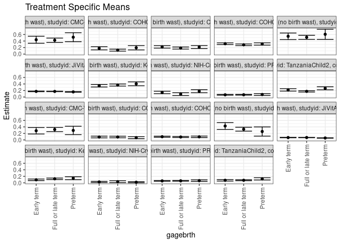

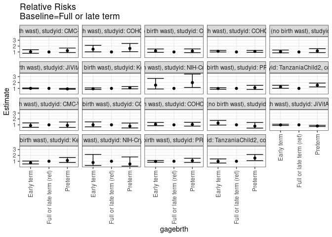

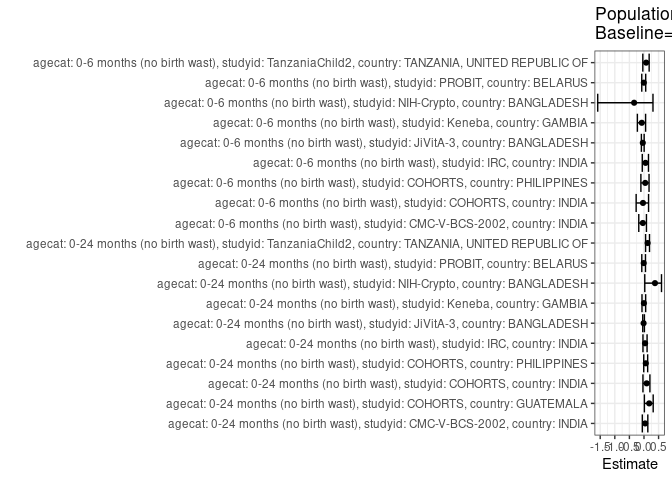

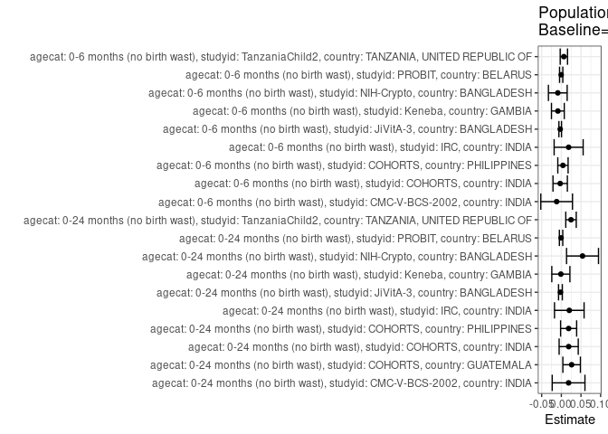

## Results Table

### Parameter: TSM

| agecat | studyid | country | intervention_level | baseline_level | estimate | ci_lower | ci_upper |
| --- | --- | --- | --- | --- | --- | --- | --- |
| 0-24 months (no birth wast) | CMC-V-BCS-2002 | INDIA | Full or late term | NA | 0.4241141 | 0.3576871 | 0.4905411 |
| 0-24 months (no birth wast) | CMC-V-BCS-2002 | INDIA | Preterm | NA | 0.5168221 | 0.3790460 | 0.6545981 |
| 0-24 months (no birth wast) | CMC-V-BCS-2002 | INDIA | Early term | NA | 0.4400139 | 0.3325362 | 0.5474915 |
| 0-24 months (no birth wast) | COHORTS | GUATEMALA | Full or late term | NA | 0.1208878 | 0.0905370 | 0.1512386 |
| 0-24 months (no birth wast) | COHORTS | GUATEMALA | Preterm | NA | 0.1938843 | 0.1280816 | 0.2596870 |
| 0-24 months (no birth wast) | COHORTS | GUATEMALA | Early term | NA | 0.1779991 | 0.1293221 | 0.2266762 |
| 0-24 months (no birth wast) | COHORTS | INDIA | Full or late term | NA | 0.1857616 | 0.1540042 | 0.2175190 |
| 0-24 months (no birth wast) | COHORTS | INDIA | Preterm | NA | 0.2151148 | 0.1700537 | 0.2601759 |
| 0-24 months (no birth wast) | COHORTS | INDIA | Early term | NA | 0.2203061 | 0.1830487 | 0.2575635 |
| 0-24 months (no birth wast) | COHORTS | PHILIPPINES | Full or late term | NA | 0.2844952 | 0.2586120 | 0.3103783 |
| 0-24 months (no birth wast) | COHORTS | PHILIPPINES | Preterm | NA | 0.3096671 | 0.2738302 | 0.3455040 |
| 0-24 months (no birth wast) | COHORTS | PHILIPPINES | Early term | NA | 0.3179779 | 0.2918459 | 0.3441099 |
| 0-24 months (no birth wast) | IRC | INDIA | Full or late term | NA | 0.5144821 | 0.4521467 | 0.5768176 |
| 0-24 months (no birth wast) | IRC | INDIA | Preterm | NA | 0.6064883 | 0.4512999 | 0.7616767 |
| 0-24 months (no birth wast) | IRC | INDIA | Early term | NA | 0.5448097 | 0.4445624 | 0.6450571 |
| 0-24 months (no birth wast) | JiVitA-3 | BANGLADESH | Full or late term | NA | 0.1708903 | 0.1637313 | 0.1780493 |
| 0-24 months (no birth wast) | JiVitA-3 | BANGLADESH | Preterm | NA | 0.1567663 | 0.1460026 | 0.1675299 |
| 0-24 months (no birth wast) | JiVitA-3 | BANGLADESH | Early term | NA | 0.1722551 | 0.1624261 | 0.1820840 |
| 0-24 months (no birth wast) | Keneba | GAMBIA | Full or late term | NA | 0.3670807 | 0.3346495 | 0.3995119 |
| 0-24 months (no birth wast) | Keneba | GAMBIA | Preterm | NA | 0.4040471 | 0.3440150 | 0.4640792 |
| 0-24 months (no birth wast) | Keneba | GAMBIA | Early term | NA | 0.3457208 | 0.3074239 | 0.3840177 |
| 0-24 months (no birth wast) | NIH-Crypto | BANGLADESH | Full or late term | NA | 0.0893176 | 0.0463025 | 0.1323327 |
| 0-24 months (no birth wast) | NIH-Crypto | BANGLADESH | Preterm | NA | 0.1774566 | 0.1312326 | 0.2236807 |
| 0-24 months (no birth wast) | NIH-Crypto | BANGLADESH | Early term | NA | 0.1388470 | 0.1011292 | 0.1765648 |
| 0-24 months (no birth wast) | PROBIT | BELARUS | Full or late term | NA | 0.0686766 | 0.0562787 | 0.0810745 |
| 0-24 months (no birth wast) | PROBIT | BELARUS | Preterm | NA | 0.0764673 | 0.0486831 | 0.1042514 |
| 0-24 months (no birth wast) | PROBIT | BELARUS | Early term | NA | 0.0671792 | 0.0543402 | 0.0800183 |
| 0-24 months (no birth wast) | TanzaniaChild2 | TANZANIA, UNITED REPUBLIC OF | Full or late term | NA | 0.1729820 | 0.1530381 | 0.1929259 |
| 0-24 months (no birth wast) | TanzaniaChild2 | TANZANIA, UNITED REPUBLIC OF | Preterm | NA | 0.2666246 | 0.2197479 | 0.3135013 |
| 0-24 months (no birth wast) | TanzaniaChild2 | TANZANIA, UNITED REPUBLIC OF | Early term | NA | 0.2173872 | 0.1815767 | 0.2531976 |
| 0-6 months (no birth wast) | CMC-V-BCS-2002 | INDIA | Full or late term | NA | 0.3191699 | 0.2542798 | 0.3840601 |
| 0-6 months (no birth wast) | CMC-V-BCS-2002 | INDIA | Preterm | NA | 0.2910806 | 0.1629312 | 0.4192299 |
| 0-6 months (no birth wast) | CMC-V-BCS-2002 | INDIA | Early term | NA | 0.2819089 | 0.1825016 | 0.3813162 |
| 0-6 months (no birth wast) | COHORTS | INDIA | Full or late term | NA | 0.0894264 | 0.0648110 | 0.1140418 |
| 0-6 months (no birth wast) | COHORTS | INDIA | Preterm | NA | 0.0696066 | 0.0393447 | 0.0998684 |
| 0-6 months (no birth wast) | COHORTS | INDIA | Early term | NA | 0.0892413 | 0.0621724 | 0.1163101 |
| 0-6 months (no birth wast) | COHORTS | PHILIPPINES | Full or late term | NA | 0.0900986 | 0.0735991 | 0.1065982 |
| 0-6 months (no birth wast) | COHORTS | PHILIPPINES | Preterm | NA | 0.0953331 | 0.0723285 | 0.1183377 |
| 0-6 months (no birth wast) | COHORTS | PHILIPPINES | Early term | NA | 0.0985921 | 0.0816858 | 0.1154984 |
| 0-6 months (no birth wast) | IRC | INDIA | Full or late term | NA | 0.3291298 | 0.2692848 | 0.3889748 |
| 0-6 months (no birth wast) | IRC | INDIA | Preterm | NA | 0.2583655 | 0.1172681 | 0.3994629 |
| 0-6 months (no birth wast) | IRC | INDIA | Early term | NA | 0.4263873 | 0.3224346 | 0.5303400 |
| 0-6 months (no birth wast) | JiVitA-3 | BANGLADESH | Full or late term | NA | 0.0732210 | 0.0681014 | 0.0783407 |
| 0-6 months (no birth wast) | JiVitA-3 | BANGLADESH | Preterm | NA | 0.0590489 | 0.0521639 | 0.0659338 |
| 0-6 months (no birth wast) | JiVitA-3 | BANGLADESH | Early term | NA | 0.0723121 | 0.0656358 | 0.0789884 |
| 0-6 months (no birth wast) | Keneba | GAMBIA | Full or late term | NA | 0.1244836 | 0.1010738 | 0.1478933 |
| 0-6 months (no birth wast) | Keneba | GAMBIA | Preterm | NA | 0.1414302 | 0.0969330 | 0.1859274 |
| 0-6 months (no birth wast) | Keneba | GAMBIA | Early term | NA | 0.0932280 | 0.0689643 | 0.1174916 |
| 0-6 months (no birth wast) | NIH-Crypto | BANGLADESH | Full or late term | NA | 0.0357143 | 0.0076336 | 0.0637950 |
| 0-6 months (no birth wast) | NIH-Crypto | BANGLADESH | Preterm | NA | 0.0192308 | 0.0025263 | 0.0359353 |
| 0-6 months (no birth wast) | NIH-Crypto | BANGLADESH | Early term | NA | 0.0280374 | 0.0099665 | 0.0461083 |
| 0-6 months (no birth wast) | PROBIT | BELARUS | Full or late term | NA | 0.0615995 | 0.0497817 | 0.0734172 |
| 0-6 months (no birth wast) | PROBIT | BELARUS | Preterm | NA | 0.0676070 | 0.0441191 | 0.0910949 |
| 0-6 months (no birth wast) | PROBIT | BELARUS | Early term | NA | 0.0597738 | 0.0476077 | 0.0719399 |
| 0-6 months (no birth wast) | TanzaniaChild2 | TANZANIA, UNITED REPUBLIC OF | Full or late term | NA | 0.0795174 | 0.0652222 | 0.0938126 |
| 0-6 months (no birth wast) | TanzaniaChild2 | TANZANIA, UNITED REPUBLIC OF | Preterm | NA | 0.1225584 | 0.0877012 | 0.1574156 |
| 0-6 months (no birth wast) | TanzaniaChild2 | TANZANIA, UNITED REPUBLIC OF | Early term | NA | 0.0786079 | 0.0552580 | 0.1019578 |

### Parameter: E(Y)

| agecat | studyid | country | intervention_level | baseline_level | estimate | ci_lower | ci_upper |
| --- | --- | --- | --- | --- | --- | --- | --- |
| 0-24 months (no birth wast) | CMC-V-BCS-2002 | INDIA | NA | NA | 0.4425287 | 0.3902692 | 0.4947882 |
| 0-24 months (no birth wast) | COHORTS | GUATEMALA | NA | NA | 0.1470952 | 0.1226726 | 0.1715178 |
| 0-24 months (no birth wast) | COHORTS | INDIA | NA | NA | 0.2044610 | 0.1828992 | 0.2260227 |
| 0-24 months (no birth wast) | COHORTS | PHILIPPINES | NA | NA | 0.3030404 | 0.2865732 | 0.3195077 |
| 0-24 months (no birth wast) | IRC | INDIA | NA | NA | 0.5347044 | 0.4850733 | 0.5843354 |
| 0-24 months (no birth wast) | JiVitA-3 | BANGLADESH | NA | NA | 0.1686060 | 0.1631976 | 0.1740145 |
| 0-24 months (no birth wast) | Keneba | GAMBIA | NA | NA | 0.3658392 | 0.3428819 | 0.3887966 |
| 0-24 months (no birth wast) | NIH-Crypto | BANGLADESH | NA | NA | 0.1432361 | 0.1182149 | 0.1682572 |
| 0-24 months (no birth wast) | PROBIT | BELARUS | NA | NA | 0.0680135 | 0.0562135 | 0.0798135 |
| 0-24 months (no birth wast) | TanzaniaChild2 | TANZANIA, UNITED REPUBLIC OF | NA | NA | 0.1975914 | 0.1811057 | 0.2140772 |
| 0-6 months (no birth wast) | CMC-V-BCS-2002 | INDIA | NA | NA | 0.3072289 | 0.2575285 | 0.3569293 |
| 0-6 months (no birth wast) | COHORTS | INDIA | NA | NA | 0.0864692 | 0.0708761 | 0.1020623 |
| 0-6 months (no birth wast) | COHORTS | PHILIPPINES | NA | NA | 0.0942127 | 0.0837084 | 0.1047169 |
| 0-6 months (no birth wast) | IRC | INDIA | NA | NA | 0.3477089 | 0.2991827 | 0.3962350 |
| 0-6 months (no birth wast) | JiVitA-3 | BANGLADESH | NA | NA | 0.0703622 | 0.0666948 | 0.0740296 |
| 0-6 months (no birth wast) | Keneba | GAMBIA | NA | NA | 0.1156550 | 0.0998052 | 0.1315047 |
| 0-6 months (no birth wast) | NIH-Crypto | BANGLADESH | NA | NA | 0.0267023 | 0.0151493 | 0.0382553 |
| 0-6 months (no birth wast) | PROBIT | BELARUS | NA | NA | 0.0612233 | 0.0502388 | 0.0722078 |
| 0-6 months (no birth wast) | TanzaniaChild2 | TANZANIA, UNITED REPUBLIC OF | NA | NA | 0.0859445 | 0.0743193 | 0.0975697 |

### Parameter: RR

| agecat | studyid | country | intervention_level | baseline_level | estimate | ci_lower | ci_upper |
| --- | --- | --- | --- | --- | --- | --- | --- |
| 0-24 months (no birth wast) | CMC-V-BCS-2002 | INDIA | Full or late term | Full or late term | 1.0000000 | 1.0000000 | 1.0000000 |
| 0-24 months (no birth wast) | CMC-V-BCS-2002 | INDIA | Preterm | Full or late term | 1.2185920 | 0.8935815 | 1.6618143 |
| 0-24 months (no birth wast) | CMC-V-BCS-2002 | INDIA | Early term | Full or late term | 1.0374893 | 0.7772053 | 1.3849418 |
| 0-24 months (no birth wast) | COHORTS | GUATEMALA | Full or late term | Full or late term | 1.0000000 | 1.0000000 | 1.0000000 |
| 0-24 months (no birth wast) | COHORTS | GUATEMALA | Preterm | Full or late term | 1.6038373 | 1.0517615 | 2.4457008 |
| 0-24 months (no birth wast) | COHORTS | GUATEMALA | Early term | Full or late term | 1.4724330 | 1.0152465 | 2.1355000 |
| 0-24 months (no birth wast) | COHORTS | INDIA | Full or late term | Full or late term | 1.0000000 | 1.0000000 | 1.0000000 |
| 0-24 months (no birth wast) | COHORTS | INDIA | Preterm | Full or late term | 1.1580154 | 0.8844960 | 1.5161174 |
| 0-24 months (no birth wast) | COHORTS | INDIA | Early term | Full or late term | 1.1859612 | 0.9337516 | 1.5062935 |
| 0-24 months (no birth wast) | COHORTS | PHILIPPINES | Full or late term | Full or late term | 1.0000000 | 1.0000000 | 1.0000000 |
| 0-24 months (no birth wast) | COHORTS | PHILIPPINES | Preterm | Full or late term | 1.0884791 | 0.9399341 | 1.2604997 |
| 0-24 months (no birth wast) | COHORTS | PHILIPPINES | Early term | Full or late term | 1.1176917 | 0.9891155 | 1.2629815 |
| 0-24 months (no birth wast) | IRC | INDIA | Full or late term | Full or late term | 1.0000000 | 1.0000000 | 1.0000000 |
| 0-24 months (no birth wast) | IRC | INDIA | Preterm | Full or late term | 1.1788325 | 0.8878056 | 1.5652594 |
| 0-24 months (no birth wast) | IRC | INDIA | Early term | Full or late term | 1.0589478 | 0.8497728 | 1.3196122 |
| 0-24 months (no birth wast) | JiVitA-3 | BANGLADESH | Full or late term | Full or late term | 1.0000000 | 1.0000000 | 1.0000000 |
| 0-24 months (no birth wast) | JiVitA-3 | BANGLADESH | Preterm | Full or late term | 0.9173502 | 0.8488990 | 0.9913210 |
| 0-24 months (no birth wast) | JiVitA-3 | BANGLADESH | Early term | Full or late term | 1.0079862 | 0.9411199 | 1.0796033 |
| 0-24 months (no birth wast) | Keneba | GAMBIA | Full or late term | Full or late term | 1.0000000 | 1.0000000 | 1.0000000 |
| 0-24 months (no birth wast) | Keneba | GAMBIA | Preterm | Full or late term | 1.1007037 | 0.9261389 | 1.3081717 |
| 0-24 months (no birth wast) | Keneba | GAMBIA | Early term | Full or late term | 0.9418115 | 0.8177488 | 1.0846960 |
| 0-24 months (no birth wast) | NIH-Crypto | BANGLADESH | Full or late term | Full or late term | 1.0000000 | 1.0000000 | 1.0000000 |
| 0-24 months (no birth wast) | NIH-Crypto | BANGLADESH | Preterm | Full or late term | 1.9868043 | 1.1484197 | 3.4372375 |
| 0-24 months (no birth wast) | NIH-Crypto | BANGLADESH | Early term | Full or late term | 1.5545307 | 0.8937711 | 2.7037858 |
| 0-24 months (no birth wast) | PROBIT | BELARUS | Full or late term | Full or late term | 1.0000000 | 1.0000000 | 1.0000000 |
| 0-24 months (no birth wast) | PROBIT | BELARUS | Preterm | Full or late term | 1.1134397 | 0.8105981 | 1.5294237 |
| 0-24 months (no birth wast) | PROBIT | BELARUS | Early term | Full or late term | 0.9781970 | 0.8545649 | 1.1197152 |
| 0-24 months (no birth wast) | TanzaniaChild2 | TANZANIA, UNITED REPUBLIC OF | Full or late term | Full or late term | 1.0000000 | 1.0000000 | 1.0000000 |
| 0-24 months (no birth wast) | TanzaniaChild2 | TANZANIA, UNITED REPUBLIC OF | Preterm | Full or late term | 1.5413429 | 1.2491567 | 1.9018734 |
| 0-24 months (no birth wast) | TanzaniaChild2 | TANZANIA, UNITED REPUBLIC OF | Early term | Full or late term | 1.2567039 | 1.0279888 | 1.5363052 |
| 0-6 months (no birth wast) | CMC-V-BCS-2002 | INDIA | Full or late term | Full or late term | 1.0000000 | 1.0000000 | 1.0000000 |
| 0-6 months (no birth wast) | CMC-V-BCS-2002 | INDIA | Preterm | Full or late term | 0.9119924 | 0.5612754 | 1.4818574 |
| 0-6 months (no birth wast) | CMC-V-BCS-2002 | INDIA | Early term | Full or late term | 0.8832564 | 0.5877791 | 1.3272705 |
| 0-6 months (no birth wast) | COHORTS | INDIA | Full or late term | Full or late term | 1.0000000 | 1.0000000 | 1.0000000 |
| 0-6 months (no birth wast) | COHORTS | INDIA | Preterm | Full or late term | 0.7783671 | 0.4652452 | 1.3022282 |
| 0-6 months (no birth wast) | COHORTS | INDIA | Early term | Full or late term | 0.9979296 | 0.6624177 | 1.5033771 |
| 0-6 months (no birth wast) | COHORTS | PHILIPPINES | Full or late term | Full or late term | 1.0000000 | 1.0000000 | 1.0000000 |
| 0-6 months (no birth wast) | COHORTS | PHILIPPINES | Preterm | Full or late term | 1.0580971 | 0.7815154 | 1.4325623 |
| 0-6 months (no birth wast) | COHORTS | PHILIPPINES | Early term | Full or late term | 1.0942681 | 0.8514731 | 1.4062953 |
| 0-6 months (no birth wast) | IRC | INDIA | Full or late term | Full or late term | 1.0000000 | 1.0000000 | 1.0000000 |
| 0-6 months (no birth wast) | IRC | INDIA | Preterm | Full or late term | 0.7849957 | 0.4412681 | 1.3964714 |
| 0-6 months (no birth wast) | IRC | INDIA | Early term | Full or late term | 1.2954989 | 0.9554530 | 1.7565672 |
| 0-6 months (no birth wast) | JiVitA-3 | BANGLADESH | Full or late term | Full or late term | 1.0000000 | 1.0000000 | 1.0000000 |
| 0-6 months (no birth wast) | JiVitA-3 | BANGLADESH | Preterm | Full or late term | 0.8064467 | 0.7063002 | 0.9207931 |
| 0-6 months (no birth wast) | JiVitA-3 | BANGLADESH | Early term | Full or late term | 0.9875872 | 0.8811547 | 1.1068756 |
| 0-6 months (no birth wast) | Keneba | GAMBIA | Full or late term | Full or late term | 1.0000000 | 1.0000000 | 1.0000000 |
| 0-6 months (no birth wast) | Keneba | GAMBIA | Preterm | Full or late term | 1.1361359 | 0.7873827 | 1.6393613 |
| 0-6 months (no birth wast) | Keneba | GAMBIA | Early term | Full or late term | 0.7489180 | 0.5433540 | 1.0322518 |
| 0-6 months (no birth wast) | NIH-Crypto | BANGLADESH | Full or late term | Full or late term | 1.0000000 | 1.0000000 | 1.0000000 |
| 0-6 months (no birth wast) | NIH-Crypto | BANGLADESH | Preterm | Full or late term | 0.5384615 | 0.1668478 | 1.7377568 |
| 0-6 months (no birth wast) | NIH-Crypto | BANGLADESH | Early term | Full or late term | 0.7850467 | 0.2840280 | 2.1698509 |
| 0-6 months (no birth wast) | PROBIT | BELARUS | Full or late term | Full or late term | 1.0000000 | 1.0000000 | 1.0000000 |
| 0-6 months (no birth wast) | PROBIT | BELARUS | Preterm | Full or late term | 1.0975252 | 0.7972724 | 1.5108532 |
| 0-6 months (no birth wast) | PROBIT | BELARUS | Early term | Full or late term | 0.9703626 | 0.8353803 | 1.1271555 |
| 0-6 months (no birth wast) | TanzaniaChild2 | TANZANIA, UNITED REPUBLIC OF | Full or late term | Full or late term | 1.0000000 | 1.0000000 | 1.0000000 |
| 0-6 months (no birth wast) | TanzaniaChild2 | TANZANIA, UNITED REPUBLIC OF | Preterm | Full or late term | 1.5412781 | 1.1008237 | 2.1579642 |
| 0-6 months (no birth wast) | TanzaniaChild2 | TANZANIA, UNITED REPUBLIC OF | Early term | Full or late term | 0.9885625 | 0.6987405 | 1.3985964 |

### Parameter: PAR

| agecat | studyid | country | intervention_level | baseline_level | estimate | ci_lower | ci_upper |
| --- | --- | --- | --- | --- | --- | --- | --- |
| 0-24 months (no birth wast) | CMC-V-BCS-2002 | INDIA | Full or late term | NA | 0.0184146 | -0.0232362 | 0.0600654 |
| 0-24 months (no birth wast) | COHORTS | GUATEMALA | Full or late term | NA | 0.0262074 | 0.0038890 | 0.0485258 |
| 0-24 months (no birth wast) | COHORTS | INDIA | Full or late term | NA | 0.0186993 | -0.0056333 | 0.0430319 |
| 0-24 months (no birth wast) | COHORTS | PHILIPPINES | Full or late term | NA | 0.0185452 | -0.0018736 | 0.0389641 |
| 0-24 months (no birth wast) | IRC | INDIA | Full or late term | NA | 0.0202222 | -0.0174311 | 0.0578756 |
| 0-24 months (no birth wast) | JiVitA-3 | BANGLADESH | Full or late term | NA | -0.0022843 | -0.0070758 | 0.0025072 |
| 0-24 months (no birth wast) | Keneba | GAMBIA | Full or late term | NA | -0.0012415 | -0.0242810 | 0.0217981 |
| 0-24 months (no birth wast) | NIH-Crypto | BANGLADESH | Full or late term | NA | 0.0539185 | 0.0132710 | 0.0945659 |
| 0-24 months (no birth wast) | PROBIT | BELARUS | Full or late term | NA | -0.0006631 | -0.0049519 | 0.0036257 |
| 0-24 months (no birth wast) | TanzaniaChild2 | TANZANIA, UNITED REPUBLIC OF | Full or late term | NA | 0.0246094 | 0.0112832 | 0.0379356 |
| 0-6 months (no birth wast) | CMC-V-BCS-2002 | INDIA | Full or late term | NA | -0.0119410 | -0.0522679 | 0.0283859 |
| 0-6 months (no birth wast) | COHORTS | INDIA | Full or late term | NA | -0.0029572 | -0.0212506 | 0.0153362 |
| 0-6 months (no birth wast) | COHORTS | PHILIPPINES | Full or late term | NA | 0.0041140 | -0.0089963 | 0.0172243 |
| 0-6 months (no birth wast) | IRC | INDIA | Full or late term | NA | 0.0185791 | -0.0183277 | 0.0554860 |
| 0-6 months (no birth wast) | JiVitA-3 | BANGLADESH | Full or late term | NA | -0.0028588 | -0.0062007 | 0.0004831 |
| 0-6 months (no birth wast) | Keneba | GAMBIA | Full or late term | NA | -0.0088286 | -0.0251091 | 0.0074519 |
| 0-6 months (no birth wast) | NIH-Crypto | BANGLADESH | Full or late term | NA | -0.0090120 | -0.0328503 | 0.0148263 |
| 0-6 months (no birth wast) | PROBIT | BELARUS | Full or late term | NA | -0.0003762 | -0.0045176 | 0.0037652 |
| 0-6 months (no birth wast) | TanzaniaChild2 | TANZANIA, UNITED REPUBLIC OF | Full or late term | NA | 0.0064271 | -0.0029020 | 0.0157562 |

### Parameter: PAF

| agecat | studyid | country | intervention_level | baseline_level | estimate | ci_lower | ci_upper |
| --- | --- | --- | --- | --- | --- | --- | --- |
| 0-24 months (no birth wast) | CMC-V-BCS-2002 | INDIA | Full or late term | NA | 0.0416123 | -0.0573595 | 0.1313200 |
| 0-24 months (no birth wast) | COHORTS | GUATEMALA | Full or late term | NA | 0.1781663 | 0.0137313 | 0.3151860 |
| 0-24 months (no birth wast) | COHORTS | INDIA | Full or late term | NA | 0.0914568 | -0.0356357 | 0.2029525 |
| 0-24 months (no birth wast) | COHORTS | PHILIPPINES | Full or late term | NA | 0.0611973 | -0.0086514 | 0.1262089 |
| 0-24 months (no birth wast) | IRC | INDIA | Full or late term | NA | 0.0378195 | -0.0353393 | 0.1058087 |
| 0-24 months (no birth wast) | JiVitA-3 | BANGLADESH | Full or late term | NA | -0.0135481 | -0.0423802 | 0.0144865 |
| 0-24 months (no birth wast) | Keneba | GAMBIA | Full or late term | NA | -0.0033934 | -0.0683906 | 0.0576495 |
| 0-24 months (no birth wast) | NIH-Crypto | BANGLADESH | Full or late term | NA | 0.3764307 | 0.0269191 | 0.6004046 |
| 0-24 months (no birth wast) | PROBIT | BELARUS | Full or late term | NA | -0.0097495 | -0.0749115 | 0.0514623 |
| 0-24 months (no birth wast) | TanzaniaChild2 | TANZANIA, UNITED REPUBLIC OF | Full or late term | NA | 0.1245470 | 0.0548929 | 0.1890676 |
| 0-6 months (no birth wast) | CMC-V-BCS-2002 | INDIA | Full or late term | NA | -0.0388669 | -0.1787473 | 0.0844141 |
| 0-6 months (no birth wast) | COHORTS | INDIA | Full or late term | NA | -0.0341997 | -0.2686892 | 0.1569496 |
| 0-6 months (no birth wast) | COHORTS | PHILIPPINES | Full or late term | NA | 0.0436673 | -0.1060172 | 0.1730941 |
| 0-6 months (no birth wast) | IRC | INDIA | Full or late term | NA | 0.0534330 | -0.0588674 | 0.1538231 |
| 0-6 months (no birth wast) | JiVitA-3 | BANGLADESH | Full or late term | NA | -0.0406298 | -0.0891316 | 0.0057121 |
| 0-6 months (no birth wast) | Keneba | GAMBIA | Full or late term | NA | -0.0763357 | -0.2264329 | 0.0553918 |
| 0-6 months (no birth wast) | NIH-Crypto | BANGLADESH | Full or late term | NA | -0.3375000 | -1.5855791 | 0.3081216 |
| 0-6 months (no birth wast) | PROBIT | BELARUS | Full or late term | NA | -0.0061446 | -0.0761003 | 0.0592633 |
| 0-6 months (no birth wast) | TanzaniaChild2 | TANZANIA, UNITED REPUBLIC OF | Full or late term | NA | 0.0747820 | -0.0399845 | 0.1768836 |